# Before and After Black Rock City

## Relationship with Others and Relationship with Nature

## Relationship with Others

### Extent of Agreement With the Statement, “I Assume That People Have Only the Best Intentions”

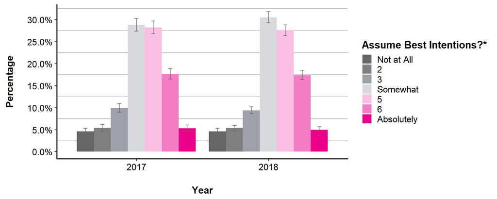

Error bars indicate the upper and lower bounds of the 95% confidence intervals.

|  | 2017 Percent | 2017 MoE +/- % |  | 2018 Percent | 2018 MoE +/- % |
| --- | --- | --- | --- | --- | --- |
| Not at All | 4.6 | 0.6 |  | 4.6 | 0.6 |
| 2 | 5.4 | 0.8 |  | 5.4 | 0.6 |
| 3 | 9.9 | 1.0 |  | 9.4 | 0.8 |
| Somewhat | 28.8 | 1.4 |  | 30.5 | 1.2 |
| 5 | 28.2 | 1.4 |  | 27.6 | 1.2 |
| 6 | 17.7 | 1.2 |  | 17.4 | 1.0 |
| Absolutely | 5.3 | 0.8 |  | 5.0 | 0.6 |

## Relationship with Others

### Helping a Stranger

In the 2018 online survey participants were also asked the question, "Please think about what you would do in the following situation. Suppose you were given 14 hours of free time off from work, and had the opportunity to spend any amount of this time from 0-14 hours, doing a personal favor for a random stranger. Outside of this favour, you would never see this person again, and the stranger would not know how much time you were given in total. If you were given 14 hours of free time, how much (from 0-14) would you spend doing a favor for the stranger?"  
Participants indicated that they would spend an average of 6.0 (+/- 0.1) hours helping the stranger.

## Relationship with Others

### Evaluation of Current Relationship Between Self and Others*

[figure not shown]

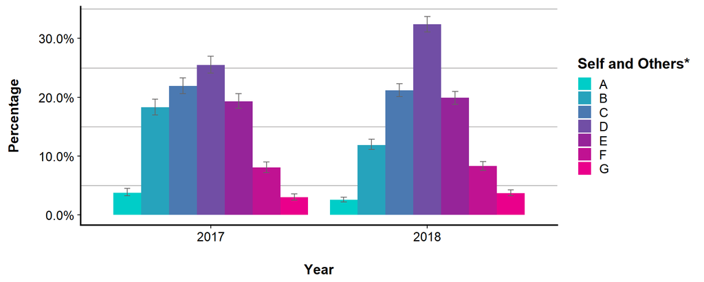

Error bars indicate the upper and lower bounds of the 95% confidence intervals.

* The exact wording of this question in the online survey was, "Please select the picture above that best describes your current relationship with other human beings, on average."

|  | 2017 Percent | 2017 MoE +/- % |  | 2018 Percent | 2018 MoE +/- % |
| --- | --- | --- | --- | --- | --- |
| A | 3.8 | 0.6 |  | 2.6 | 0.4 |
| B | 18.3 | 1.4 |  | 11.9 | 1.0 |
| C | 21.9 | 1.4 |  | 21.2 | 1.2 |
| D | 25.5 | 1.4 |  | 32.4 | 1.2 |
| E | 19.3 | 1.4 |  | 19.9 | 1.2 |
| F | 8.1 | 1.0 |  | 8.3 | 0.8 |
| G | 3.0 | 0.6 |  | 3.7 | 0.6 |

## Relationship with Nature

### Evaluation of Current Relationship Between Self and Nature*

[figure not shown]

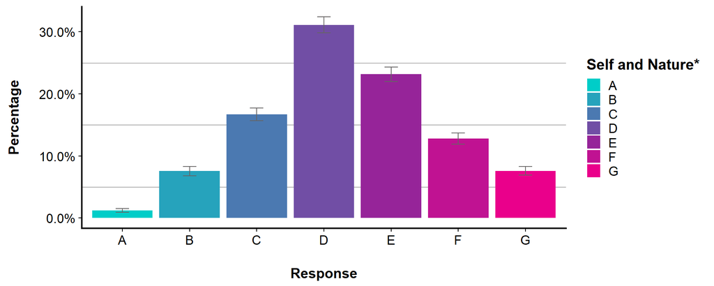

Error bars indicate the upper and lower bounds of the 95% confidence intervals.

* This question was first introduced in the 2018 online survey. The exact wording of this question in the online survey was, "Please select the picture above that best describes your relationship with the natural environment. How interconnected are you with nature? (Self = you, Nature = the environment)."

|  | 2018 Percent | 2018 MoE +/- % |
| --- | --- | --- |
| A | 1.2 | 0.2 |
| B | 7.6 | 0.8 |
| C | 16.7 | 1.0 |
| D | 31.1 | 1.2 |
| E | 23.2 | 1.2 |
| F | 12.8 | 1.0 |
| G | 7.6 | 0.8 |

## Relationship with Nature

### Self-Identification with Specified Group Labels*

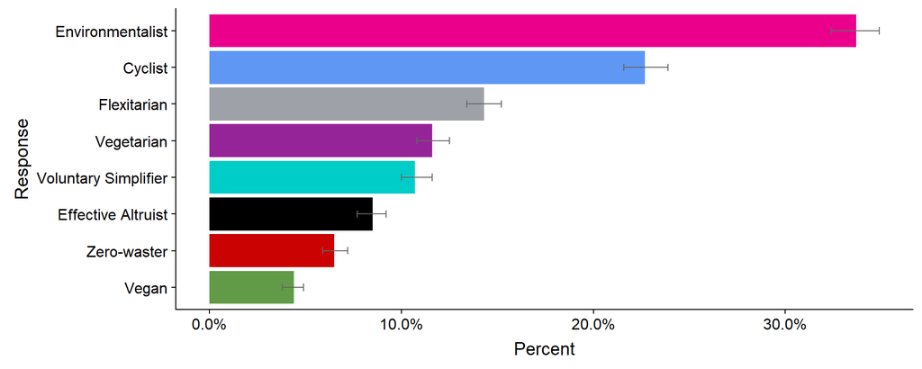

Error bars indicate the upper and lower bounds of the 95% confidence intervals.

* This question was first introduced in the 2018 online survey. Participants selected all option(s) that applied.

|  | 2018 Percent | 2018 MoE +/- % |
| --- | --- | --- |
| Environmentalist | 33.7 | 1.2 |
| Cyclist | 22.7 | 1.2 |
| Flexitarian | 14.3 | 1.0 |
| Vegetarian | 11.6 | 0.8 |
| Voluntary Simplifier | 10.7 | 0.8 |
| Effective Altruist | 8.5 | 0.8 |
| Zero-waster | 6.5 | 0.6 |
| Vegan | 4.4 | 0.6 |

## Relationship with Nature

### Environmental Perspectives*

Participants were asked to use a scale to indicate the degree to which they agreed with the statement below, from “Strongly Disagree” to “Strongly Agree.” The plot and table below represent responses for the statement:

*“I think of myself as an environmentally-friendly consumer.”*

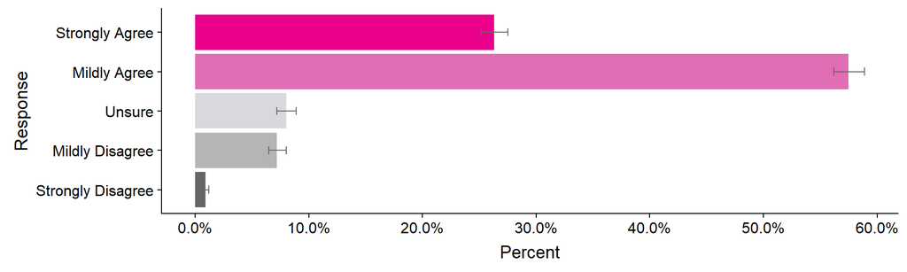

Error bars indicate the upper and lower bounds of the 95% confidence intervals.

* This question set was first introduced in the 2018 online survey.

|  | 2018 Percent | 2018 MoE +/- % |
| --- | --- | --- |
| Strongly Agree | 26.3 | 1.2 |
| Mildly Agree | 57.5 | 1.4 |
| Unsure | 8.0 | 0.8 |
| Mildly Disagree | 7.2 | 0.8 |
| Strongly Disagree | 0.9 | 0.2 |

## Relationship with Nature

### Environmental Perspectives*

Participants were asked to use a scale to indicate the degree to which they agreed with the statement below, from “Strongly Disagree” to “Strongly Agree.” The plot and table below represent responses for the statement:

*“I think of myself as someone who is very concerned with environmental issues.”*

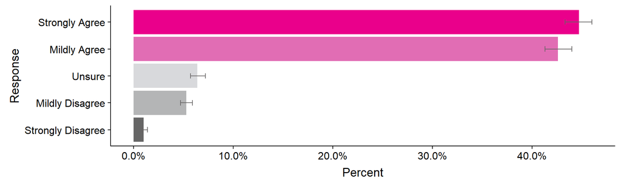

Error bars indicate the upper and lower bounds of the 95% confidence intervals.

* This question set was first introduced in the 2018 online survey.

|  | 2018 Percent | 2018 MoE +/- % |
| --- | --- | --- |
| Strongly Agree | 44.7 | 1.4 |
| Mildly Agree | 42.6 | 1.4 |
| Unsure | 6.4 | 0.8 |
| Mildly Disagree | 5.3 | 0.6 |
| Strongly Disagree | 1.0 | 0.2 |

## Relationship with Nature

### Environmental Perspectives*

Participants were asked to use a scale to indicate the degree to which they agreed with the statement below, from “Strongly Disagree” to “Strongly Agree.” The plot and table below represent responses for the statement:

*“I would be embarrassed to be seen as having an environmentally-friendly lifestyle.”*

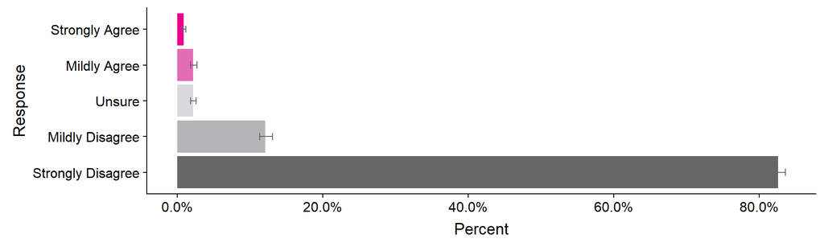

Error bars indicate the upper and lower bounds of the 95% confidence intervals.

* This question set was first introduced in the 2018 online survey.

|  | 2018 Percent | 2018 MoE +/- % |
| --- | --- | --- |
| Strongly Agree | 0.9 | 0.2 |
| Mildly Agree | 2.2 | 0.4 |
| Unsure | 2.2 | 0.4 |
| Mildly Disagree | 12.1 | 1.0 |
| Strongly Disagree | 82.6 | 1.0 |

## Relationship with Nature

### Environmental Perspectives*

Participants were asked to use a scale to indicate the degree to which they agreed with the statement below, from “Strongly Disagree” to “Strongly Agree.” The plot and table below represent responses for the statement:

*“I would not want my family or friends to think of me as someone who is concerned about environmental issues.”*

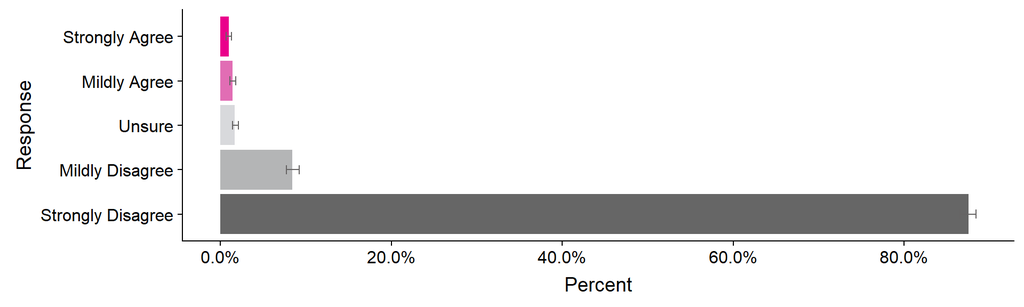

Error bars indicate the upper and lower bounds of the 95% confidence intervals.

* This question set was first introduced in the 2018 online survey.

|  | 2018 Percent | 2018 MoE +/- % |
| --- | --- | --- |
| Strongly Agree | 1.0 | 0.2 |
| Mildly Agree | 1.4 | 0.4 |
| Unsure | 1.7 | 0.4 |
| Mildly Disagree | 8.4 | 0.8 |
| Strongly Disagree | 87.5 | 1.0 |

## Relationship with Nature

### Humans and Nature*

Participants were asked to use a scale to indicate the degree to which they agreed with the statement below, from “Strongly Disagree” to “Strongly Agree.” The plot and table below represent responses for the statement:

*“Humans have the right to modify the natural environment to suit their needs.”*

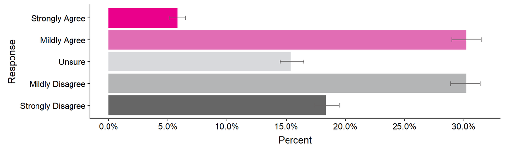

Error bars indicate the upper and lower bounds of the 95% confidence intervals.

* This question set was first introduced in the 2018 online survey.

|  | 2018 Percent | 2018 MoE +/- % |
| --- | --- | --- |
| Strongly Agree | 5.8 | 0.6 |
| Mildly Agree | 30.2 | 1.2 |
| Unsure | 15.4 | 1.0 |
| Mildly Disagree | 30.2 | 1.2 |
| Strongly Disagree | 18.4 | 1.0 |

## Relationship with Nature

### Humans and Nature*

Participants were asked to use a scale to indicate the degree to which they agreed with the statement below, from “Strongly Disagree” to “Strongly Agree.” The plot and table below represent responses for the statement:

*“Humans are severely abusing the planet.”*

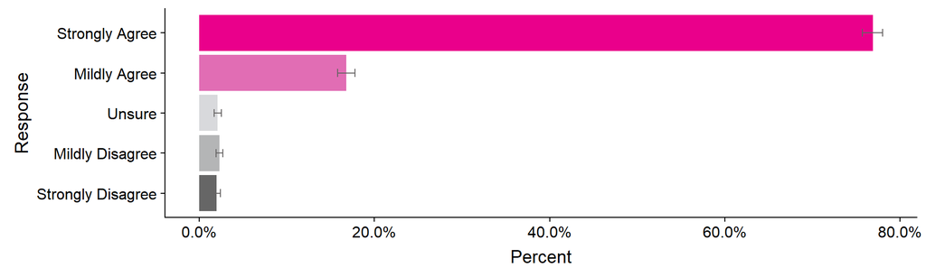

Error bars indicate the upper and lower bounds of the 95% confidence intervals.

* This question set was first introduced in the 2018 online survey.

|  | 2018 Percent | 2018 MoE +/- % |
| --- | --- | --- |
| Strongly Agree | 76.9 | 1.2 |
| Mildly Agree | 16.8 | 1.0 |
| Unsure | 2.1 | 0.4 |
| Mildly Disagree | 2.3 | 0.4 |
| Strongly Disagree | 2.0 | 0.4 |

## Relationship with Nature

### Humans and Nature*

Participants were asked to use a scale to indicate the degree to which they agreed with the statement below, from “Strongly Disagree” to “Strongly Agree.” The plot and table below represent responses for the statement:

*“Plants and animals have the same rights as humans to exist.”*

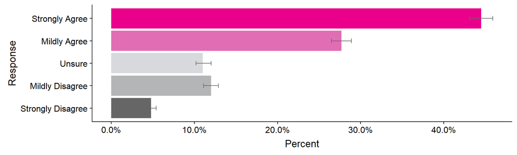

Error bars indicate the upper and lower bounds of the 95% confidence intervals.

* This question set was first introduced in the 2018 online survey.

|  | 2018 Percent | 2018 MoE +/- % |
| --- | --- | --- |
| Strongly Agree | 44.5 | 1.4 |
| Mildly Agree | 27.7 | 1.2 |
| Unsure | 11.0 | 1.0 |
| Mildly Disagree | 12.0 | 1.0 |
| Strongly Disagree | 4.8 | 0.6 |

## Relationship with Nature

### Humans and Nature*

Participants were asked to use a scale to indicate the degree to which they agreed with the statement below, from “Strongly Disagree” to “Strongly Agree.” The plot and table below represent responses for the statement:

*“Nature is strong enough to cope with the impact of modern industrial nations.”*

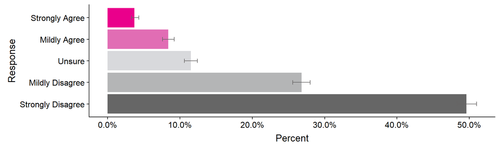

Error bars indicate the upper and lower bounds of the 95% confidence intervals.

* This question set was first introduced in the 2018 online survey.

|  | 2018 Percent | 2018 MoE +/- % |
| --- | --- | --- |
| Strongly Agree | 3.7 | 0.6 |
| Mildly Agree | 8.4 | 0.8 |
| Unsure | 11.5 | 0.8 |
| Mildly Disagree | 26.8 | 1.2 |
| Strongly Disagree | 49.6 | 1.4 |

## Relationship with Nature

### Humans and Nature*

Participants were asked to use a scale to indicate the degree to which they agreed with the statement below, from “Strongly Disagree” to “Strongly Agree.” The plot and table below represent responses for the statement:

*“Humans were meant to rule over the rest of nature.”*

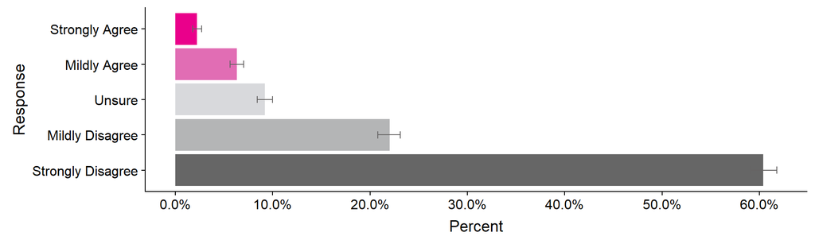

Error bars indicate the upper and lower bounds of the 95% confidence intervals.

* This question set was first introduced in the 2018 online survey.

|  | 2018 Percent | 2018 MoE +/- % |
| --- | --- | --- |
| Strongly Agree | 2.2 | 0.4 |
| Mildly Agree | 6.3 | 0.8 |
| Unsure | 9.2 | 0.8 |
| Mildly Disagree | 22.0 | 1.2 |
| Strongly Disagree | 60.4 | 1.4 |

## Relationship with Nature

### Humans and Nature*

Participants were asked to use a scale to indicate the degree to which they agreed with the statement below, from “Strongly Disagree” to “Strongly Agree.” The plot and table below represent responses for the statement:

*“The balance of nature is very delicate and easily upset.”*

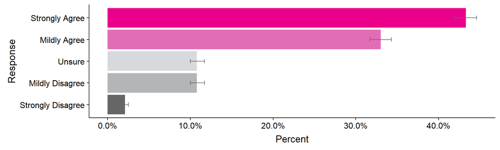

Error bars indicate the upper and lower bounds of the 95% confidence intervals.

* This question set was first introduced in the 2018 online survey.

|  | 2018 Percent | 2018 MoE +/- % |
| --- | --- | --- |
| Strongly Agree | 43.3 | 1.4 |
| Mildly Agree | 33.0 | 1.4 |
| Unsure | 10.8 | 0.8 |
| Mildly Disagree | 10.8 | 0.8 |
| Strongly Disagree | 2.1 | 0.4 |

**Next:** Before and After Black Rock City: Increased Open-Mindedness and Comparing Settings